# Reproducible Research: Storm data

Joris Van den Bossche

31 augustus 2016

# Synopsis

# Data Processing

## Reading the data

Obtaining the data from the internet can be done by running this code.

```r
download.file("https://d396qusza40orc.cloudfront.net/repdata%2Fdata%2FStormData.csv.bz2","data.csv.bz2")
```

For reference, documentation can be found following [this url](https://d396qusza40orc.cloudfront.net/repdata%2Fpeer2_doc%2Fpd01016005curr.pdf).  
Loading the data into R is done by this simple command. It may take a couple of minutes.

```r
stormData <- read.csv("data.csv.bz2", stringsAsFactors = FALSE)
```

## Transforming the data

Using the data.table library, the data frame can be transformed to a data table, as such:

```r
library(data.table)
stormData <- as.data.table(stormData)
```

# Results

## Health

In this section we will look at which events cause the most fatalities and injuries.  
To look at the ten most deadly events, first the sum over every event type is extracted from the stormData data table. Then the data is sorted and the first 10 are extracted.

```r
healthByType <- stormData[,.(fatalities = sum(FATALITIES),
                             injuries = sum(INJURIES),
                             sum = sum(FATALITIES) + sum(INJURIES)),
                          by = EVTYPE][order(-sum)]
healthByType[1:10]
```

```
##                EVTYPE fatalities injuries   sum
##  1:           TORNADO       5633    91346 96979
##  2:    EXCESSIVE HEAT       1903     6525  8428
##  3:         TSTM WIND        504     6957  7461
##  4:             FLOOD        470     6789  7259
##  5:         LIGHTNING        816     5230  6046
##  6:              HEAT        937     2100  3037
##  7:       FLASH FLOOD        978     1777  2755
##  8:         ICE STORM         89     1975  2064
##  9: THUNDERSTORM WIND        133     1488  1621
## 10:      WINTER STORM        206     1321  1527
```

Tornadoes are the leading cause in casualties, followed by excessive heat and thunderstorms (TSTM WIND).

To construct a plot, the data frame first has to be melted, so fatalities and injuries can be represented next to each other. Then the plot can be constructed.

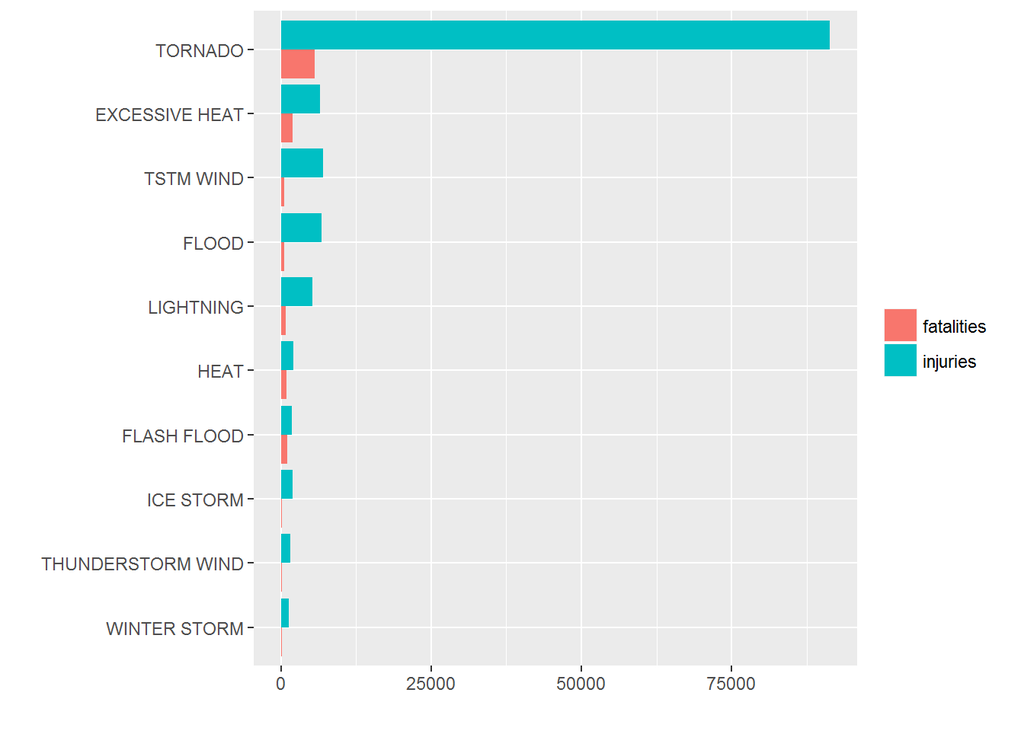

```r
library(ggplot2)
ggplot(data = melt(healthByType[1:10, 1:3, with = FALSE], id.vars = "EVTYPE")) +
  geom_bar(aes(x = reorder(EVTYPE,value),
               value,
               fill = variable),
           stat='identity',
           position="dodge") +
  coord_flip() +
  labs(x = "", y = "") +
  theme(legend.title=element_blank())
```

The severity of an event can be described with the ratio of fatalities to the total of injured or fatalities reported in the event.

```r
healthByType[, ratio := fatalities/(fatalities+injuries)]
healthByType[injuries > 10,][order(-ratio)][1:10]
```

```
##                      EVTYPE fatalities injuries sum     ratio
##  1:         COLD/WIND CHILL         95       12 107 0.8878505
##  2: EXTREME COLD/WIND CHILL        125       24 149 0.8389262
##  3:             RIP CURRENT        368      232 600 0.6133333
##  4:               HURRICANE         61       46 107 0.5700935
##  5:               AVALANCHE        224      170 394 0.5685279
##  6:       FLOOD/FLASH FLOOD         17       15  32 0.5312500
##  7:    HEAVY SURF/HIGH SURF         42       48  90 0.4666667
##  8:               LANDSLIDE         38       52  90 0.4222222
##  9:                    COLD         35       48  83 0.4216867
## 10:            EXTREME COLD        160      231 391 0.4092072
```

Above table shows wind chills and rip currents are especially deadly.

## Economy

This section will be looking at the economical damage. As with the health information data, the sum over every event type is extracted from the stormData data table. Then the data is sorted and the first 10 are extracted.

```r
econDmgByType <- stormData[,.(propdmg = sum(PROPDMG),
                              cropdmg = sum(CROPDMG),
                              sumdmg = sum(PROPDMG)+sum(CROPDMG)),
                           by = EVTYPE][order(-sumdmg)]
econDmgByType[1:10]
```

```
##                 EVTYPE   propdmg   cropdmg    sumdmg
##  1:            TORNADO 3212258.2 100018.52 3312276.7
##  2:        FLASH FLOOD 1420124.6 179200.46 1599325.1
##  3:          TSTM WIND 1335965.6 109202.60 1445168.2
##  4:               HAIL  688693.4 579596.28 1268289.7
##  5:              FLOOD  899938.5 168037.88 1067976.4
##  6:  THUNDERSTORM WIND  876844.2  66791.45  943635.6
##  7:          LIGHTNING  603351.8   3580.61  606932.4
##  8: THUNDERSTORM WINDS  446293.2  18684.93  464978.1
##  9:          HIGH WIND  324731.6  17283.21  342014.8
## 10:       WINTER STORM  132720.6   1978.99  134699.6
```

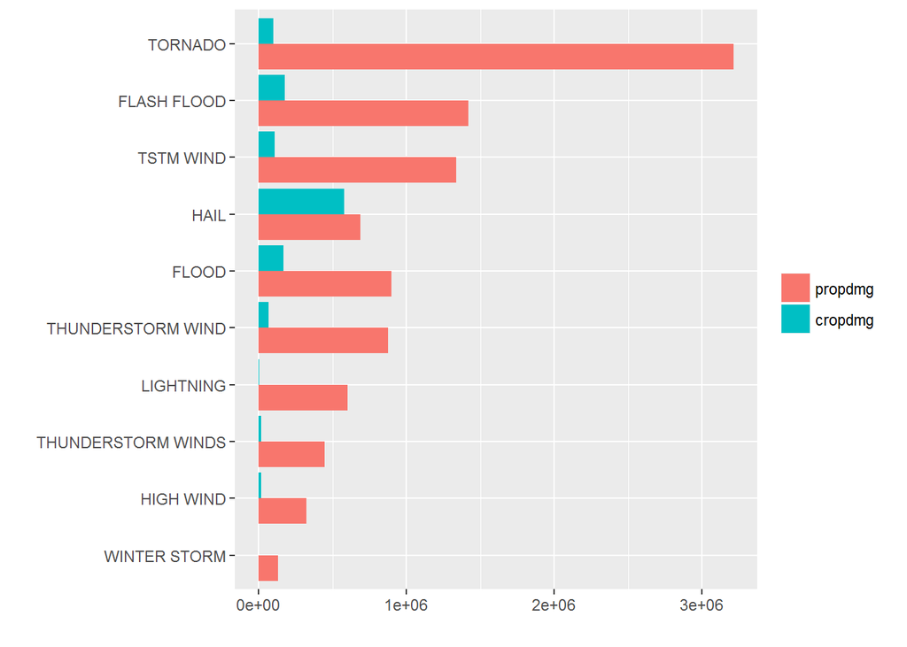

```r
ggplot(data = melt(econDmgByType[1:10, 1:3, with = FALSE], id.vars = "EVTYPE")) +
  geom_bar(aes(x = reorder(EVTYPE,value),
               value,
               fill = variable),
           stat='identity',
           position="dodge") +
  coord_flip() +
  labs(x = "", y = "") +
  theme(legend.title=element_blank())
```

The most damaging events to property are found in the next table:

```r
econDmgByType[order(-propdmg), 1:2, with = FALSE][1:10]
```

```
##                 EVTYPE   propdmg
##  1:            TORNADO 3212258.2
##  2:        FLASH FLOOD 1420124.6
##  3:          TSTM WIND 1335965.6
##  4:              FLOOD  899938.5
##  5:  THUNDERSTORM WIND  876844.2
##  6:               HAIL  688693.4
##  7:          LIGHTNING  603351.8
##  8: THUNDERSTORM WINDS  446293.2
##  9:          HIGH WIND  324731.6
## 10:       WINTER STORM  132720.6
```

In line with the overall damagee, it is tornadoes, flash floods and thunderstorms (TSTM WIND).  
The most damaging events to crops can be found in the next table:

```r
econDmgByType[order(-cropdmg), c(1,3), with = FALSE][1:10]
```

```
##                 EVTYPE   cropdmg
##  1:               HAIL 579596.28
##  2:        FLASH FLOOD 179200.46
##  3:              FLOOD 168037.88
##  4:          TSTM WIND 109202.60
##  5:            TORNADO 100018.52
##  6:  THUNDERSTORM WIND  66791.45
##  7:            DROUGHT  33898.62
##  8: THUNDERSTORM WINDS  18684.93
##  9:          HIGH WIND  17283.21
## 10:         HEAVY RAIN  11122.80
```

Here can be concluded hail to be the leading cause of crop damage, followed by flash floods and floods.